# Supervised Learning - Foundations Project: ReCell

#### **Back Camera and Brand Analysis**

```python
df_main_camera = df[df.main_camera_mp > 16]
df_main_camera.shape
```

```
(94, 15)
```

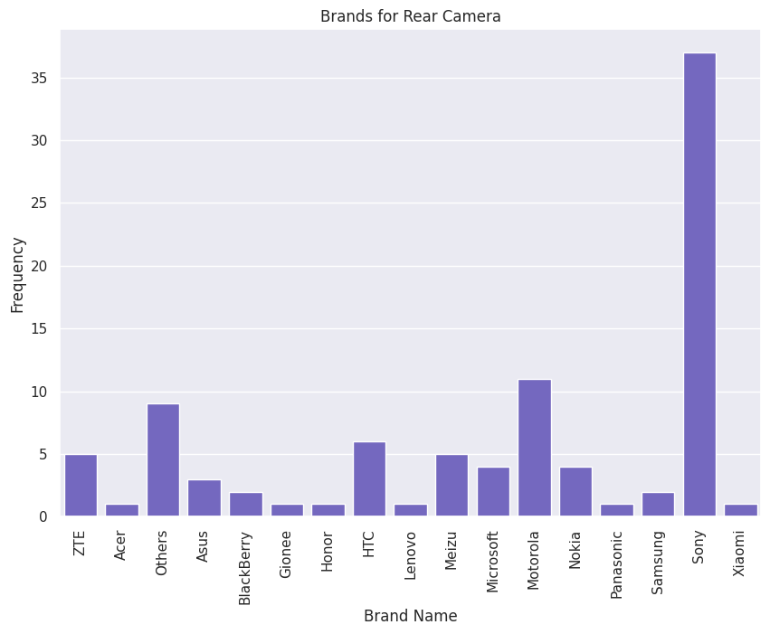

```python
plt.figure(figsize=(10,7))
plt.title("Brands for Rear Camera")
plt.xlabel('Brand Name')
plt.ylabel('Frequency')

sns.countplot(data=df_main_camera, x='brand_name', color='slateblue')
plt.xticks(rotation=90)
plt.show()
```

#### **Price Over Time Analysis**

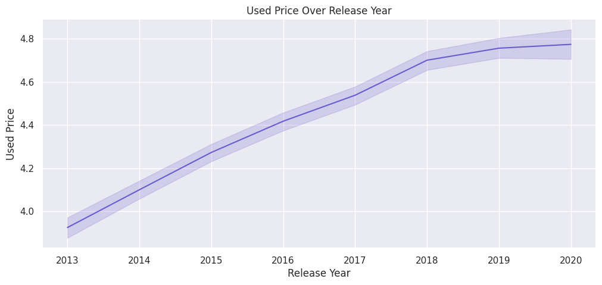

```python
plt.figure(figsize=(12, 5))
plt.figure(figsize=(12, 5))
sns.lineplot(data=data, x='release_year', y='normalized_used_price',color='slateblue')
plt.title('Used Price Over Release Year')
plt.xlabel('Release Year')
plt.ylabel('Used Price')
plt.show()
```

#### **Price Variation between used phones and tablets for 4G & 5G Networks**

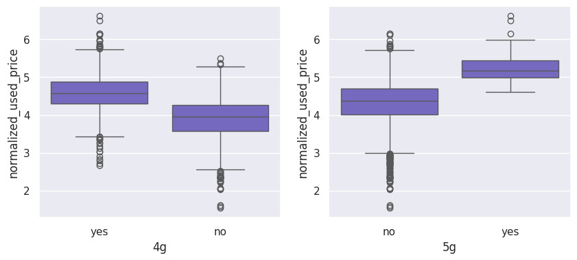

```python
plt.figure(figsize=(10, 4))

plt.subplot(121)
sns.boxplot(data=df, x="4g", y="normalized_used_price",color='slateblue')

plt.subplot(122)
sns.boxplot(data=df, x="5g", y="normalized_used_price",color='slateblue')

plt.show()
```

```python
total_devices = len(df)

android = df['os'].str.contains('Android', case=False).sum()

# Calculate the percentage of Android devices among all used devices
android_percentage = (android / total_devices) * 100

# Print the result
print("Percentage of used device market dominated by Android devices: {:.2f}%".format(android_percentage))
```

```
Percentage of used device market dominated by Android devices: 93.05%
```

```python
#screen count for over 6 inches
phones_count = 0
tablets_count = 0

for screen_size_cm in df['screen_size']:
    # do the math from inches to centimeters (15.24 cm)
    if screen_size_cm > 15.24:

        phones_count += 1

print("Number of phones and tablets with screen size > 6 inches:", phones_count)
```

```
Number of phones and tablets with screen size > 6 inches: 1099
```

### Answers to questions for EDA:

1.What does the distribution of normalized used device prices look like?

```
* Its a normal distribution
```

1. What percentage of the used device market is dominated by Android devices?

```
* 93.05%
```

1. The amount of RAM is important for the smooth functioning of a device. How does the amount of RAM vary with the brand?

```
* The brands with lots of options for ram did have more users from the box plot we saw up abobe.
```

1. A large battery often increases a device's weight, making it feel uncomfortable in the hands. How does the weight vary for phones and tablets offering large batteries (more than 4500 mAh)?

```
*  Based on the plot above, people clearly don't care much about the battery weight since the ones with the higher battery weights still had a large amount of users. In the regression model we even remove the battery column since it doesn't impact the price much.
```

1. Bigger screens are desirable for entertainment purposes as they offer a better viewing experience. How many phones and tablets are available across different brands with a screen size larger than 6 inches?

```
* There are 1099 devices with a phone screen over 6 inches.
```

1. A lot of devices nowadays offer great selfie cameras, allowing us to capture our favorite moments with loved ones. What is the distribution of devices offering greater than 8MP selfie cameras across brands?

```
* It would be a right tailed distribution.
```

1. Which attributes are highly correlated with the normalized price of a used device?

```
* Front and back camera, screen size, ram, weight
```

## Data Preprocessing

- Missing value treatment
- Feature engineering (if needed)
- Outlier detection and treatment (if needed)
- Preparing data for modeling
- Any other preprocessing steps (if needed)

### Missing Value Treatment

```python
#Make another copy
df1 = data.copy()

# Check for missing values
missing_values = df1.isnull().sum()

# Display missing values
print("Missing values:\n", missing_values)
```

```
Missing values:
 brand_name                 0
os                         0
screen_size                0
4g                         0
5g                         0
main_camera_mp           179
selfie_camera_mp           2
int_memory                 4
ram                        4
battery                    6
weight                     7
release_year               0
days_used                  0
normalized_used_price      0
normalized_new_price       0
dtype: int64
```

```python
cols_impute = [
    "main_camera_mp",
    "selfie_camera_mp",
    "int_memory",
    "ram",
    "battery",
    "weight",
]

for col in cols_impute:
    df1[col] = df1[col].fillna(
        value=df1.groupby(['release_year', 'brand_name'])[col].transform("median")
    )

# checking for missing values
missing_values_after_imputation = df1.isnull().sum()
print("Missing values after imputation:\n", missing_values_after_imputation)
```

```
Missing values after imputation:
 brand_name                 0
os                         0
screen_size                0
4g                         0
5g                         0
main_camera_mp           179
selfie_camera_mp           2
int_memory                 0
ram                        0
battery                    6
weight                     7
release_year               0
days_used                  0
normalized_used_price      0
normalized_new_price       0
dtype: int64
```

```python
df1["main_camera_mp"] = df1["main_camera_mp"].fillna(df1["main_camera_mp"].median())
missing_values_after_imputation = df1.isnull().sum()

df1["selfie_camera_mp"] = df1["selfie_camera_mp"].fillna(df1["selfie_camera_mp"].median())
missing_values_after_imputation = df1.isnull().sum()

df1["weight"] = df1["weight"].fillna(df1["weight"].median())
missing_values_after_imputation = df1.isnull().sum()

df1["battery"] = df1["battery"].fillna(df1["battery"].median())
missing_values_after_imputation = df1.isnull().sum()

print("Missing values after imputation:\n", missing_values_after_imputation)
```

```
Missing values after imputation:
 brand_name               0
os                       0
screen_size              0
4g                       0
5g                       0
main_camera_mp           0
selfie_camera_mp         0
int_memory               0
ram                      0
battery                  0
weight                   0
release_year             0
days_used                0
normalized_used_price    0
normalized_new_price     0
dtype: int64
```

### Feature Engineering

```python
df1["years_since_release"] = 2021 - df1["release_year"]
df1.drop("release_year", axis=1, inplace=True)
df1["years_since_release"].describe()
```

```
count    3454.000000
mean        5.034742
std         2.298455
min         1.000000
25%         3.000000
50%         5.500000
75%         7.000000
max         8.000000
Name: years_since_release, dtype: float64
```

### Outlier Check

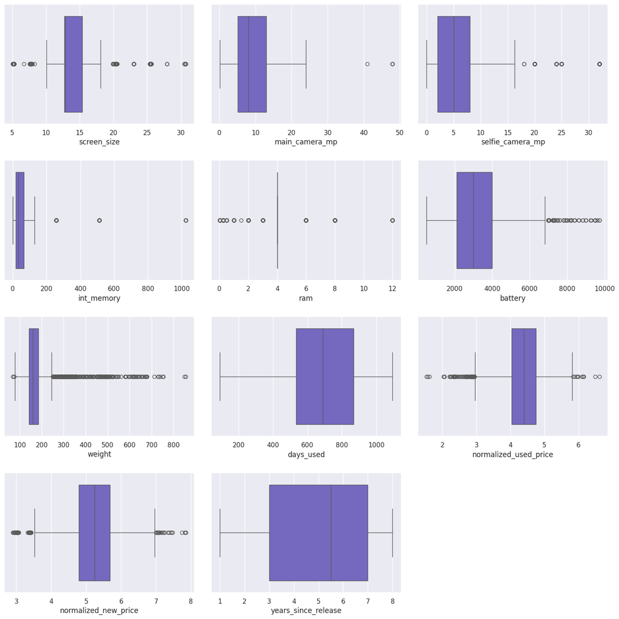

```python
# outlier detection using boxplot
num_cols = df1.select_dtypes(include=np.number).columns.tolist()

plt.figure(figsize=(15, 15))

for i, variable in enumerate(num_cols):
    plt.subplot(4, 3, i + 1)
    sns.boxplot(data=df1, x=variable,color='slateblue')
    plt.tight_layout(pad=2)

plt.show()
```

### Data Preparation for Modeling

```python
## Complete the code to define the dependent and independent variables
# Defining dependent and independent variables
x = df1[[ 'screen_size','4g', '5g','main_camera_mp', 'selfie_camera_mp',
        'int_memory', 'ram', 'battery', 'weight', 'years_since_release', 'days_used','normalized_new_price']]
y = df1['normalized_used_price']

print(x.head())
print()
print(y.head())

print("Length of x:", len(x))
print("Length of y:", len(y))

# let's add the intercept to data
X = sm.add_constant(x)

# creating dummy variables
x = pd.get_dummies(x, columns=x.select_dtypes(include=["object", "category"]).columns.tolist(), drop_first=True)

 ## Complete the code to create dummies for independent features
print(x.head())
x.head()
# splitting the data in 70:30 ratio for train to test data

x_train, x_test, y_train, y_test = train_test_split(x, y, test_size=0.3, random_state=42)
print("Number of rows in train data =", x_train.shape[0])
print("Number of rows in test data =", x_test.shape[0])
```

```
   screen_size   4g   5g  main_camera_mp  selfie_camera_mp  int_memory  ram  \
0        14.50  yes   no            13.0               5.0        64.0  3.0
1        17.30  yes  yes            13.0              16.0       128.0  8.0
2        16.69  yes  yes            13.0               8.0       128.0  8.0
3        25.50  yes  yes            13.0               8.0        64.0  6.0
4        15.32  yes   no            13.0               8.0        64.0  3.0

   battery  weight  years_since_release  days_used  normalized_new_price
0   3020.0   146.0                    1        127              4.715100
1   4300.0   213.0                    1        325              5.519018
2   4200.0   213.0                    1        162              5.884631
3   7250.0   480.0                    1        345              5.630961
4   5000.0   185.0                    1        293              4.947837

0    4.307572
1    5.162097
2    5.111084
3    5.135387
4    4.389995
Name: normalized_used_price, dtype: float64
Length of x: 3454
Length of y: 3454
   screen_size  main_camera_mp  selfie_camera_mp  int_memory  ram  battery  \
0        14.50            13.0               5.0        64.0  3.0   3020.0
1        17.30            13.0              16.0       128.0  8.0   4300.0
2        16.69            13.0               8.0       128.0  8.0   4200.0
3        25.50            13.0               8.0        64.0  6.0   7250.0
4        15.32            13.0               8.0        64.0  3.0   5000.0

   weight  years_since_release  days_used  normalized_new_price  4g_yes  \
0   146.0                    1        127              4.715100    True
1   213.0                    1        325              5.519018    True
2   213.0                    1        162              5.884631    True
3   480.0                    1        345              5.630961    True
4   185.0                    1        293              4.947837    True

   5g_yes
0   False
1    True
2    True
3    True
4   False
Number of rows in train data = 2417
Number of rows in test data = 1037
```

## EDA

- It is a good idea to explore the data once again after manipulating it.

since linear regression needs to have numerical values im going to drop some columns and then convert the 4g and 5g to binary for the yes and no

## Model Building - Linear Regression

```python
olsmodel1 = sm.OLS(y_train, x_train.astype(float))
olsres = olsmodel1.fit()
# let's print the regression summary
print(olsres.summary())
```

[output not shown]

## Model Performance Check

```python
# function to compute adjusted R-squared
def adj_r2_score(predictors, targets, predictions):
    r2 = r2_score(targets, predictions)
    n = predictors.shape[0]
    k = predictors.shape[1]
    return 1 - ((1 - r2) * (n - 1) / (n - k - 1))


# function to compute MAPE
def mape_score(targets, predictions):
    return np.mean(np.abs(targets - predictions) / targets) * 100


# function to compute different metrics to check performance of a regression model
def model_performance_regression(model, predictors, target):
    """
    Function to compute different metrics to check regression model performance

    model: regressor
    predictors: independent variables
    target: dependent variable
    """

    # predicting using the independent variables
    pred = model.predict(predictors)

    r2 = r2_score(target, pred)  # to compute R-squared
    adjr2 = adj_r2_score(predictors, target, pred)  # to compute adjusted R-squared
    rmse = np.sqrt(mean_squared_error(target, pred))  # to compute RMSE
    mae = mean_absolute_error(target, pred)  # to compute MAE
    mape = mape_score(target, pred)  # to compute MAPE

    # creating a dataframe of metrics
    df_perf = pd.DataFrame(
        {
            "RMSE": rmse,
            "MAE": mae,
            "R-squared": r2,
            "Adj. R-squared": adjr2,
            "MAPE": mape,
        },
        index=[0],
    )

    return df_perf
```

```python
# checking model performance on train set (seen 70% data)
print("Training Performance\n")
olsmodel1_train_perf = model_performance_regression(olsmodel1, x_train.astype(float), y_train)
olsmodel1_train_perf

# checking model performance on test set (seen 30% data)
print("Test Performance\n")
#olsmodel1_test_perf = model_performance_regression('_______') ## Complete the code to check the performance on test data
#olsmodel1_test_perf
```

```
Training Performance
```

[output not shown]

## Checking Linear Regression Assumptions

In order to make statistical inferences from a linear regression model, it is important to ensure that the assumptions of linear regression are satisfied. We will test for the following:

1. No Multicollinearity
2. Linearity of variables
3. Independence of error terms
4. Normality of error terms
5. No Heteroscedasticity

### Test for Multicollinearity

```python
# Let's define a function to check VIF.
def checking_vif(predictors):
    vif = pd.DataFrame()
    vif["feature"] = predictors.columns

    # calculating VIF for each feature
    vif["VIF"] = [
        variance_inflation_factor(predictors.values, i)
        for i in range(len(predictors.columns))
    ]
    return vif

# Checking VIF on the train data (x_train)
checking_vif(x_train)
```

[output not shown]

[output cut: 36 more lines]

[output not shown]

```python
from statsmodels.stats.outliers_influence import variance_inflation_factor

# Let's define a function to check VIF.
def checking_vif(predictors):
    # Convert predictors to numeric types
    predictors = predictors.apply(pd.to_numeric, errors='coerce')
    predictors = predictors.dropna()  # Drop rows with NaN values after conversion

    vif_series = pd.Series(
        [variance_inflation_factor(predictors.values, i) for i in range(predictors.shape[1])],
        index=predictors.columns,
        name='VIF'
    )

    print("VIF values: \n\n{}\n".format(vif_series))

    return vif_series

# Call the function to check VIF on train data
vif_train = checking_vif(x_train)
print("VIF DataFrame for train data:")
print(vif_train)
```

[output not shown]

[output cut: 38 more lines]

[output not shown]

removing the multicollinearity

```python
def treating_multicollinearity(predictors, target, high_vif_columns):
    """
    Checking the effect of dropping the columns showing high multicollinearity
    on model performance (adj. R-squared and RMSE)

    predictors: independent variables
    target: dependent variable
    high_vif_columns: columns having high VIF
    """
    # empty lists to store adj. R-squared and RMSE values
    adj_r2 = []
    rmse = []

    # build ols models by dropping one of the high VIF columns at a time
    # store the adjusted R-squared and RMSE in the lists defined previously
    for cols in high_vif_columns:
        # defining the new train set
        train = predictors.loc[:, ~predictors.columns.str.startswith(cols)]

        # create the model
        olsmodel = sm.OLS(target, train).fit()

        # adding adj. R-squared and RMSE to the lists
        adj_r2.append(olsmodel.rsquared_adj)
        rmse.append(np.sqrt(olsmodel.mse_resid))

    # creating a dataframe for the results
    temp = pd.DataFrame(
        {
            "col": high_vif_columns,
            "Adj. R-squared after_dropping col": adj_r2,
            "RMSE after dropping col": rmse,
        }
    ).sort_values(by="Adj. R-squared after_dropping col", ascending=False)
    temp.reset_index(drop=True, inplace=True)

    return temp
```

```python
col_list = ['battery','int_memory','years_since_release'] ## Complete the code to specify the columns with high VIF

res = treating_multicollinearity(x_train.astype(float), y_train, col_list) ## Complete the code to check the effect on model performance after dropping specified columns from train data
res
```

|  | col | Adj. R-squared after_dropping col | RMSE after dropping col |
| --- | --- | --- | --- |
| 0 | battery | 0.996207 | 0.271077 |
| 1 | int_memory | 0.996207 | 0.271077 |
| 2 | years_since_release | 0.996207 | 0.271077 |

```python
# Complete the code to specify the columns to drop
cols_to_drop = ['battery','int_memory','years_since_release']

# Loop through each column to drop
for col_to_drop in cols_to_drop:
    # Complete the code to specify the train data from which to drop the column specified
    x_train = x_train.loc[:, ~x_train.columns.str.startswith(col_to_drop)]
    # Complete the code to specify the test data from which to drop the column specified
    x_test = x_test.loc[:, ~x_test.columns.str.startswith(col_to_drop)]

# Check VIF now
vif = checking_vif(x_train.astype(float))
print("VIF after dropping ", cols_to_drop)
vif
```

```
VIF after dropping  ['battery', 'int_memory', 'years_since_release']
```

|  | feature | VIF |
| --- | --- | --- |
| 0 | screen_size | 72.336828 |
| 1 | main_camera_mp | 9.076287 |
| 2 | selfie_camera_mp | 4.018862 |
| 3 | ram | 19.117402 |
| 4 | weight | 23.613229 |
| 5 | days_used | 12.204811 |
| 6 | normalized_new_price | 65.619888 |
| 7 | 4g_yes | 5.678776 |
| 8 | 5g_yes | 1.699958 |

```python
# Train your model using the modified training data
ols_model2 = sm.OLS(y_train, x_train.astype(float)).fit()

# Make predictions on the test data
predictions = ols_model2.predict(x_test.astype(float))

# Evaluate model performance
# For example, you can print a summary of the OLS model which includes p-values
print(ols_model2.summary())
```

```
                                  OLS Regression Results
==========================================================================================
Dep. Variable:     normalized_used_price   R-squared (uncentered):                   0.996
Model:                               OLS   Adj. R-squared (uncentered):              0.996
Method:                    Least Squares   F-statistic:                          7.054e+04
Date:                   Sun, 28 Apr 2024   Prob (F-statistic):                        0.00
Time:                           03:05:17   Log-Likelihood:                         -270.03
No. Observations:                   2417   AIC:                                      558.1
Df Residuals:                       2408   BIC:                                      610.2
Df Model:                              9
Covariance Type:               nonrobust
========================================================================================
                           coef    std err          t      P>|t|      [0.025      0.975]
----------------------------------------------------------------------------------------
screen_size              0.0565      0.003     17.166      0.000       0.050       0.063
main_camera_mp           0.0115      0.002      7.270      0.000       0.008       0.015
selfie_camera_mp         0.0134      0.001     11.418      0.000       0.011       0.016
ram                      0.0243      0.006      4.283      0.000       0.013       0.035
weight                  -0.0004      0.000     -2.903      0.004      -0.001      -0.000
days_used                0.0002   2.68e-05      6.666      0.000       0.000       0.000
normalized_new_price     0.6116      0.008     72.212      0.000       0.595       0.628
4g_yes                   0.0532      0.016      3.342      0.001       0.022       0.084
5g_yes                  -0.1266      0.036     -3.546      0.000      -0.197      -0.057
==============================================================================
Omnibus:                      128.363   Durbin-Watson:                   1.991
Prob(Omnibus):                  0.000   Jarque-Bera (JB):              223.334
Skew:                          -0.412   Prob(JB):                     3.19e-49
Kurtosis:                       4.240   Cond. No.                     4.81e+03
==============================================================================

Notes:
[1] R² is computed without centering (uncentered) since the model does not contain a constant.
[2] Standard Errors assume that the covariance matrix of the errors is correctly specified.
[3] The condition number is large, 4.81e+03. This might indicate that there are
strong multicollinearity or other numerical problems.
```

Obervations:

[output not shown]

### Test for Linearity and Independence

```python
df_pred = pd.DataFrame()

df_pred["Actual Values"] = y_train
df_pred["Fitted Values"] = ols_model2.fittedvalues
df_pred["Residuals"] = ols_model2.resid

df_pred.head()
```

|  | Actual Values | Fitted Values | Residuals |
| --- | --- | --- | --- |
| 1744 | 4.261975 | 4.318608 | -0.056632 |
| 3141 | 4.175156 | 3.691250 | 0.483906 |
| 1233 | 4.117410 | 4.464324 | -0.346915 |
| 3046 | 3.782597 | 3.833035 | -0.050438 |
| 2649 | 3.981922 | 3.900392 | 0.081530 |

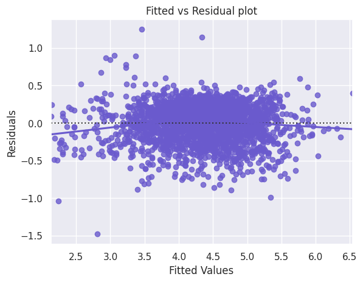

```python
# let's plot the fitted values vs residuals

sns.residplot(
    data=df_pred, x="Fitted Values", y="Residuals", color="slateblue", lowess=True
)
plt.xlabel("Fitted Values")
plt.ylabel("Residuals")
plt.title("Fitted vs Residual plot")
plt.show()
```

Observations:

```
*Our fitted versus residual graph does look good. It is very clustered, but that is because we have over 3000 records in our data.
*If the data showed some growing or increasing pattern that our data may not be meeting the linear criteria.
```

### Test for Normality

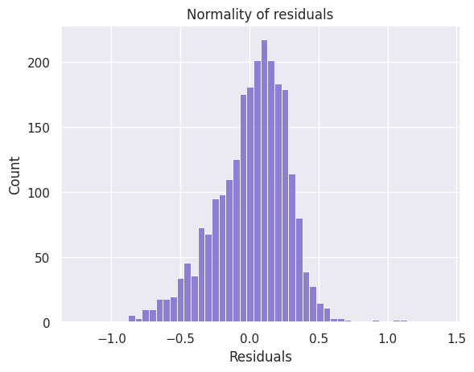

```python
sns.histplot(data=df_pred, x='Residuals', color='slateblue')
plt.title("Normality of residuals")
plt.show()
```

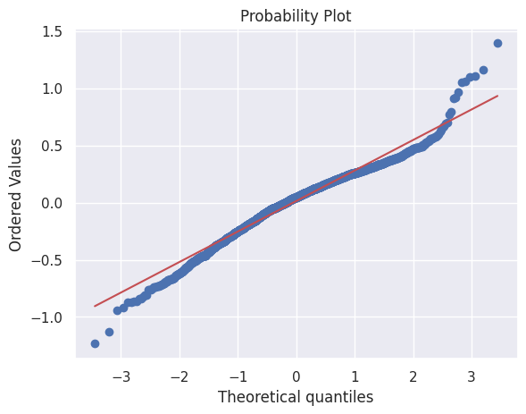

```python
import pylab
import scipy.stats as stats

stats.probplot(df_pred['Residuals'], dist="norm", plot=pylab) ## Complete the code check Q-Q plot
plt.show()
```

```python
stats.shapiro(df_pred['Residuals'])
```

```
ShapiroResult(statistic=0.9741024374961853, pvalue=1.6006358443207362e-20)
```

Observations:

[output not shown]

### Test for Homoscedasticity

```python
import statsmodels.stats.api as sms
from statsmodels.compat import lzip

import statsmodels.stats.api as sms

print("Shape of x (exog):", x.shape)
print("Shape of y (endog):", y.shape)
# Perform the Goldfeld-Quandt test using all numerical independent variables
test = sms.het_goldfeldquandt(ols_model2.resid, x.astype(float))

# Display the test results
print("Goldfeld-Quandt Test Results:")
print("F statistic:", test[0])
print("p-value:", test[1])
```

```
Shape of x (exog): (3454, 12)
Shape of y (endog): (3454,)
```

[output not shown]

[output cut: 24 more lines]

[output not shown]

Oberservations:

[output not shown]

## Final Model

```python
# Fit the final OLS model
olsmodel_final = sm.OLS(y_train, x_train.astype(float)).fit()

# Print the summary of the final model
print(olsmodel_final.summary())

# Checking model performance on the train set
print("Training Performance\n")
olsmodel_final_train_perf = model_performance_regression(olsmodel_final, x_train, y_train)
print(olsmodel_final_train_perf)

# Checking model performance on the test set
print("Test Performance\n")
olsmodel_final_test_perf = model_performance_regression(olsmodel_final, x_test, y_test)
print(olsmodel_final_test_perf)
```

```
                                  OLS Regression Results
==========================================================================================
Dep. Variable:     normalized_used_price   R-squared (uncentered):                   0.996
Model:                               OLS   Adj. R-squared (uncentered):              0.996
Method:                    Least Squares   F-statistic:                          7.054e+04
Date:                   Sun, 28 Apr 2024   Prob (F-statistic):                        0.00
Time:                           01:12:53   Log-Likelihood:                         -270.03
No. Observations:                   2417   AIC:                                      558.1
Df Residuals:                       2408   BIC:                                      610.2
Df Model:                              9
Covariance Type:               nonrobust
========================================================================================
                           coef    std err          t      P>|t|      [0.025      0.975]
----------------------------------------------------------------------------------------
screen_size              0.0565      0.003     17.166      0.000       0.050       0.063
main_camera_mp           0.0115      0.002      7.270      0.000       0.008       0.015
selfie_camera_mp         0.0134      0.001     11.418      0.000       0.011       0.016
ram                      0.0243      0.006      4.283      0.000       0.013       0.035
weight                  -0.0004      0.000     -2.903      0.004      -0.001      -0.000
days_used                0.0002   2.68e-05      6.666      0.000       0.000       0.000
normalized_new_price     0.6116      0.008     72.212      0.000       0.595       0.628
4g_yes                   0.0532      0.016      3.342      0.001       0.022       0.084
5g_yes                  -0.1266      0.036     -3.546      0.000      -0.197      -0.057
==============================================================================
Omnibus:                      128.363   Durbin-Watson:                   1.991
Prob(Omnibus):                  0.000   Jarque-Bera (JB):              223.334
Skew:                          -0.412   Prob(JB):                     3.19e-49
Kurtosis:                       4.240   Cond. No.                     4.81e+03
==============================================================================

Notes:
[1] R² is computed without centering (uncentered) since the model does not contain a constant.
[2] Standard Errors assume that the covariance matrix of the errors is correctly specified.
[3] The condition number is large, 4.81e+03. This might indicate that there are
strong multicollinearity or other numerical problems.
Training Performance

       RMSE       MAE  R-squared  Adj. R-squared      MAPE
0  0.270572  0.210696   0.790435        0.789652  5.009466
Test Performance

       RMSE       MAE  R-squared  Adj. R-squared      MAPE
0  0.270876  0.215064   0.784536        0.782648  5.087347
```

## Actionable Insights and Recommendations

```python
!pwd
```

```
/content
```

```python
%%shell
jupyter nbconvert --to html '/content/drive/MyDrive/Collab_Notebooks/Supervised Learning Foundations/Project/SLF_Project_LearnerNotebook_FullCode.ipynb'
```

```
[NbConvertApp] Converting notebook /content/drive/MyDrive/Collab_Notebooks/Supervised Learning Foundations/Project/SLF_Project_LearnerNotebook_FullCode.ipynb to html
[NbConvertApp] Writing 2621740 bytes to /content/drive/MyDrive/Collab_Notebooks/Supervised Learning Foundations/Project/SLF_Project_LearnerNotebook_FullCode.html
```